# Lab 2: Sentiment Analysis I

Luna Herschenfeld-Catalán

2024-04-16

## Assignment (Due 4/16 by 11:59 PM)

```r
knitr::opts_chunk$set(echo = TRUE)
library(LexisNexisTools)
library(dplyr)
library(readr)
library(stringr)
library(here)
library(tidytext)
library(tidyr) #pivot_wider()
library(ggplot2)
```

### Obtain your data and load it into R

- Access the Nexis Uni database through the UCSB library: https://www.library.ucsb.edu/research/db/211
- Choose a key search term or terms to define a set of articles.
- Use your search term along with appropriate filters to obtain and download a batch of at least 100 full text search results (.docx). You are limited to downloading 100 articles at a time, so if you have more results than that, you have to download them in batches (rows 1-100, 101-200, 201-300 etc.)

  Guidance for {LexisNexisTools} : https://github.com/JBGruber/LexisNexisTools/wiki/Downloading-Files-From-Nexis
- Read your Nexis article documents into RStudio.

```r
setwd("data/News_gw_policy/") #where the .docxs live
news_files <- list.files(pattern = ".docx",
                         path = getwd(),
                         full.names = TRUE, recursive = TRUE, ignore.case = TRUE)

# take files list and read them into LNT object
dat <- LexisNexisTools::lnt_read(news_files)

# reference 'slot' using @
meta_df <- dat@meta
articles_df <- dat@articles
paragraphs_df <- dat@paragraphs


# create tibble with these columns
dat2 <- tibble(Date = meta_df$Date,
               Headline = meta_df$Headline,
               id = articles_df$ID,
               text = articles_df$Article)

# paragraphs <- tibble(art_id = paragraphs_df$Art_ID,
#                     paragraph = paragraphs_df$Paragraph)

write.csv(dat2, file.path("/Users/lunacatalan/Documents/dev/eds231/eds-231-textanalysis/class/data/News_gw_policy/news.csv"))
```

- Use the full text of the articles for the analysis. Inspect the data (in particular the full-text article data).

```r
dat2$text %>%
  lnt_lookup(pattern = "Delivered by Newstex")
```

- If necessary, clean any artifacts of the data collection process (hint: this type of thing should be removed: “Apr 04, 2022( Biofuels Digest: http://www.biofuelsdigest.com/Delivered by Newstex”) and any other urls)

```r
news_df <- read_csv(here::here("class", "data", "News_gw_policy", "news.csv"))

text_clean <- news_df %>%

  # remove the urls from the text
  separate_wider_delim(text,
                       delim = "Delivered by Newstex)   ",
                       names = c("delete", "text"),
                       too_few = "align_end") %>%
  select(-delete) %>%

  # remove the notes at the end
  separate_wider_delim(text,
                       delim = "The views expressed in any and all content distributed by Newstex",
                       names = c("text", "delete"),
                       too_few = "align_start") %>%
  select(-delete) %>%

  # remove any of the urls that start with https
  mutate(text = gsub(" ?(f|ht)tp(s?)://(.*)[.][a-z]+", "",
                     text))
  #filter(Date != is.na(Date)) # remove article with NA
```

- Remove any clear duplicate articles. LNT has a method for this, but it doesn’t seem to work, so you probably need to do it manually.

```r
# check the length of unique headlines
length(unique(text_clean$Headline))
```

```
## [1] 97
```

```r
# remove the duplicates by keeping only distinct headline names
text_clean <- text_clean %>%
  distinct(Headline, .keep_all = TRUE)
  # mutate(Date = ifelse(is.na(Date),
  #                      "unk",
  #                      Date),
  #        Headline = ifelse(is.na(Headline),
  #                      "unk",
  #                      Headline))
```

### Explore your data and conduct the following analyses:

1. Calculate mean sentiment across all your articles

```r
#load the bing sentiment lexicon from tidytext
bing_sent <-  get_sentiments("bing")

text_words <- text_clean %>%
  unnest_tokens(output = word,
                input = text,
                token = "words") %>%
  anti_join(stop_words) # take out the stop words

# sentiment values in words
sent_words <- text_words %>%
  inner_join(bing_sent, by = "word") %>%
  mutate(sent_num = case_when(sentiment == "negative" ~ -1,
                              sentiment == "positive" ~ 1))
# sentiment values in articles
sent_article <- sent_words %>%
  group_by(Headline) %>%
  count(id, sentiment) %>%
  pivot_wider(names_from = sentiment,
              values_from = n) %>%
  mutate(polarity = positive - negative) %>%
  ungroup()

# calculate the mean polarity value
mean(sent_article$polarity, na.rm = TRUE)
```

```
## [1] -3.967391
```

2. Sentiment by article plot. The one provided in class needs significant improvement.

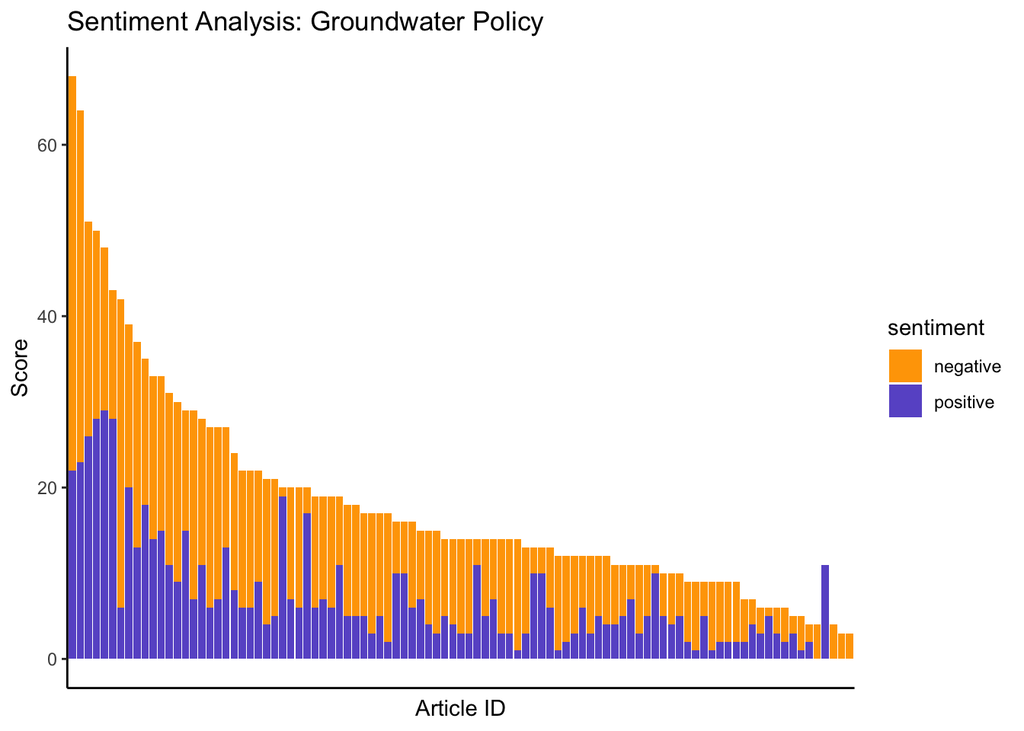

```r
sent_article_plot <- sent_article %>%
  select(id, negative, positive) %>%
  pivot_longer(!id) %>%
  rename(sentiment = name,
         score = value)

ggplot(sent_article_plot,
       aes(x = reorder(id, -score), y = score)) +
  geom_col(aes(fill = sentiment)) +
  theme_classic() +
  scale_fill_manual(values = c("positive" = "slateblue", "negative" = "orange")) +
  labs(title = "Sentiment Analysis: Groundwater Policy",
       x = "Article ID",
       y = "Score") +
  theme(axis.text.x = element_blank(),
        axis.ticks.x = element_blank())
```

3. Most common nrc emotion words and plot by emotion

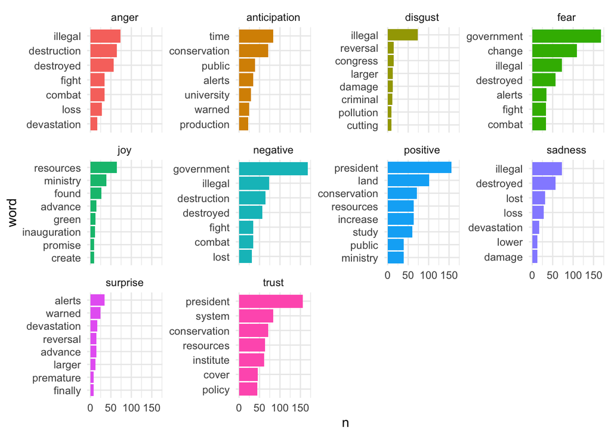

```r
nrc_sent <- get_sentiments("nrc")

nrc_word_counts <- text_words %>%
  inner_join(nrc_sent, by = "word") %>%
  count(word, sentiment, sort = T)

nrc_count_plot <- nrc_word_counts %>%
  group_by(sentiment) %>%
  slice_max(order_by = n, n = 7) %>%
  ungroup() %>%
  mutate(word = reorder(word, n))

ggplot(data = nrc_count_plot,
       aes(x = n, y = word, fill = sentiment)) +
  geom_col(show.legend = FALSE) +
  facet_wrap(~sentiment, scales = "free_y") +
  theme_minimal()
```

4. Look at the nrc contribution to emotion by word plots. Identify and reclassify or remove at least one term that gives misleading results in your context.
- Words: larger, devastation

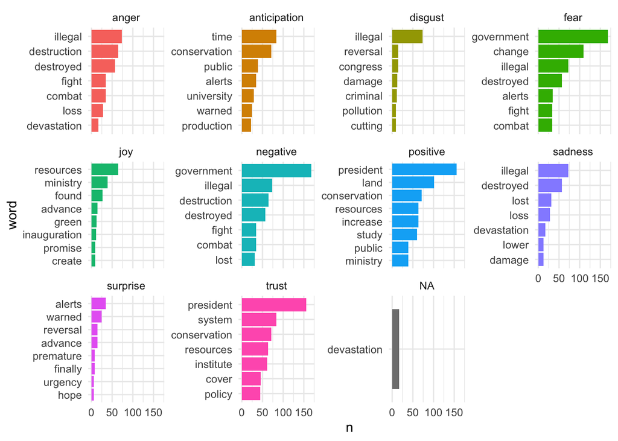

```r
# reclassify and remove terms
nrc_sent_edit <- nrc_sent %>%
  filter(word != 'larger') %>%  # remove this word
  mutate(sentiment = ifelse(word == "devastation" & sentiment == "surprise", # reclassify
         NA,
         sentiment))

# plot the new word plots
text_words %>%
  inner_join(nrc_sent_edit, by = "word") %>%
  count(word, sentiment, sort = T) %>%
  group_by(sentiment) %>%
  slice_max(order_by = n, n = 7) %>%
  ungroup() %>%
  mutate(word = reorder(word, n)) %>%
  ggplot(aes(x = n, y = word, fill = sentiment)) +
  geom_col(show.legend = FALSE) +
  facet_wrap(~sentiment, scales = "free_y") +
  theme_minimal()
```

5. Plot the amount of nrc emotion words as a percentage of all the emotion words used each day (aggregate text from articles published on the same day). How does the distribution of emotion words change over time? Can you think of any reason this would be the case?

The distribution of emotion words in 2023 did not really change over time. This might be because overall, water issues have been pretty apparent and everyone may be on the same page and the sentiments are pretty consistent.

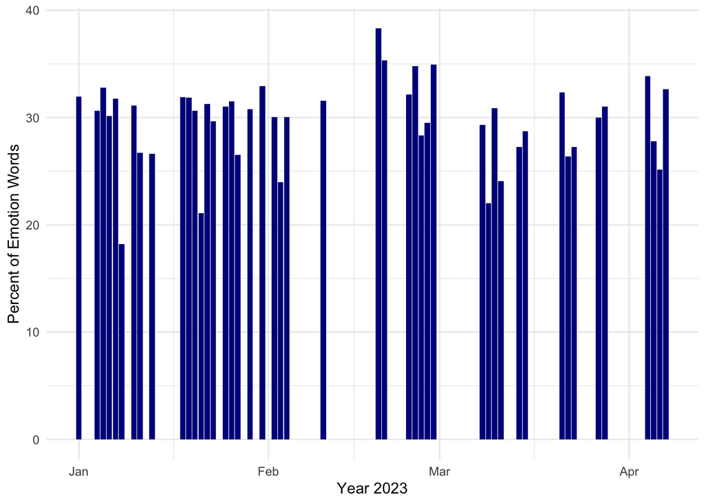

```r
nrc_word_counts_day <- text_words %>%
  left_join(nrc_sent, by = "word") %>%
  # is there an emotion word or not
  mutate(nrc_word = ifelse(is.na(sentiment),
                           "no",
                           "yes")) %>%
  group_by(Date) %>%
  count(Date, nrc_word, sort = T) %>%
  pivot_wider(names_from = nrc_word,
              values_from = n) %>%
  mutate(total = no + yes,
         nrc_percent = (yes/total)*100)

ggplot(nrc_word_counts_day, aes(x = Date, y = nrc_percent)) +
  geom_col(fill = "darkblue") +
  theme_minimal() +
  labs(x = "Year 2023",
       y = "Percent of Emotion Words")
```